# Question

A canoe travels 2.9 m/s **relative to the water**. A river, heading east, flows at 1.4 m/s. The canoe points at a direction 2.24 radians counterclockwise from east.

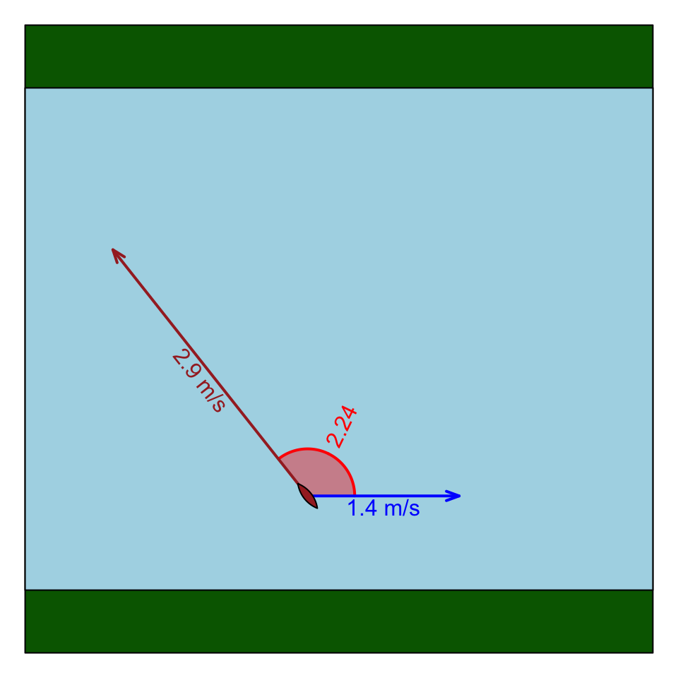

Find the canoe’s total speed, in m/s, and direction of travel, as radians counterclockwise from east. (In other words, find the canoe’s velocity **relative to the ground**, in polar form.)

## Answerlist

- 1.9
- 2.0
- 2.1
- 2.2
- 2.3
- 2.4
- 1.71
- 1.72
- 1.73
- 1.74
- 1.75
- 1.76

# Solution

First, find the [rectangular coordinates](https://en.wikipedia.org/wiki/Vector_notation#Rectangular_coordinates) of each velocity vector. The two formulas:

$$x~=~r\cdot\cos(\theta)$$
$$y~=~r\cdot\sin(\theta)$$

We will use $\vec{v}_1$ for the canoe’s velocity **relative to water**. It is shown below with approximate rectangular coordinates (found from formulas above, using $r=2.9$ and $\theta=2.24$).

$$\vec{v}_1 = (-1.799,2.275)$$

We will use $\vec{v}_2$ for the river’s velocity vector. Since the river flows directly east, all of its speed is in the positive horizontal direction.

$$\vec{v}_2 = (1.400,0.000)$$

Now, add the corresponding components to find $\vec{v}_3$, the velocity of the canoe **relative to the ground**.

$$\vec{v}_3 = (-0.399,2.275)$$

Lastly, we need to find the [polar coordinates](https://en.wikipedia.org/wiki/Vector_notation#Polar_coordinates). The formulas are given below. Notice, I am using the [two-argument arctangent](https://en.wikipedia.org/wiki/Atan2) function.

$$r~=~\sqrt{x^2+y^2}$$
$$\theta~=~\arctan(y,x)$$

So,

$$r=\sqrt{(-0.399)^2+(2.275)^2}~=~2.3092561$$

$$\theta=\arctan(2.275,-0.399)~=~1.7444721$$

This can be visualized.

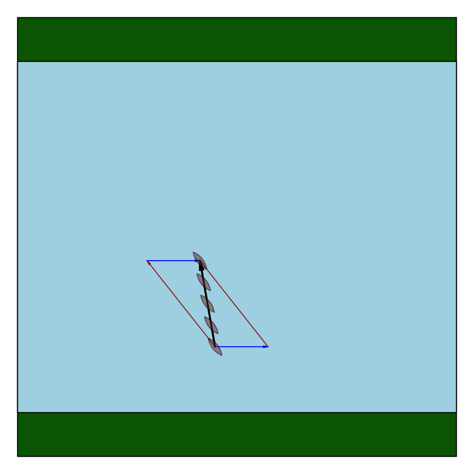

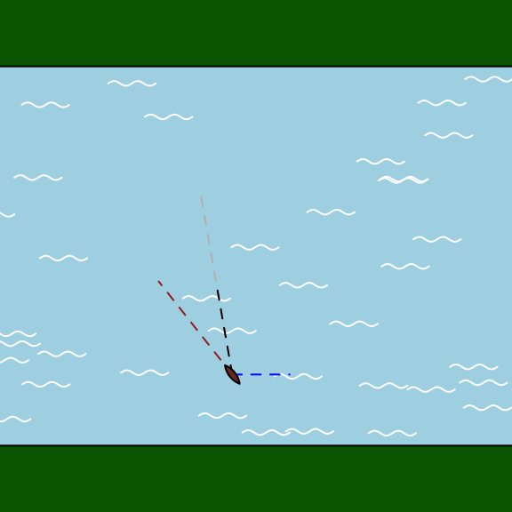

So, if we round like the answer choices, the speed of the canoe is 2.3 m/s at a direction of 1.74 radians counterclockwise from east.

# Meta-information

extype: cloze exclozetype: schoice|schoice exsolution: 000010|000100 exname: canoe_river_degs